# DESeq Analysis

Dave Bridges

August 2, 2015

This script performs the DESeq analyses on the Juvenile HFD studies. This script was most recently run on Wed Mar 16 10:13:04 2016. This uses the input data from the kallisto runs.

The counts data, derived from HTSeq are located in ../kallisto/kallisto_output. The sample mapping file is located in ../sample-mapping.csv. The annotations are from the file ENSEMBL Annotation - Transcripts.csv. The files are written out as TPM Table.csv and Estimated Counts.csv.

# Overall Analysis

The first model was a completely interacting model in which tissue, feeding state and diet were all able to interact.

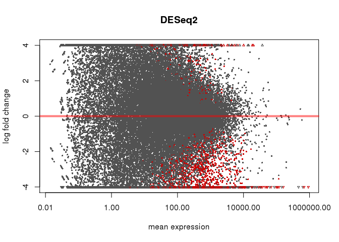

MA Plot for Overall Model

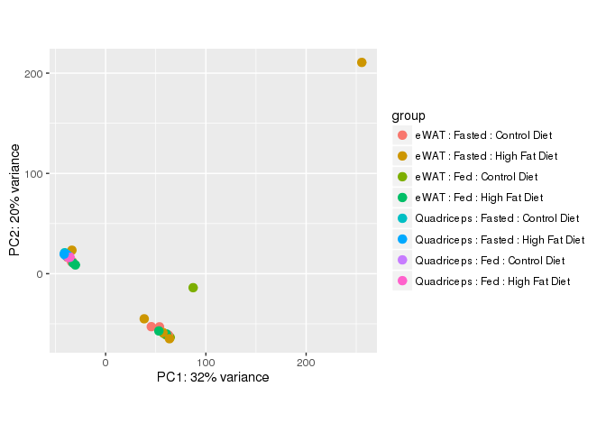

PCA Plot for Overall Model

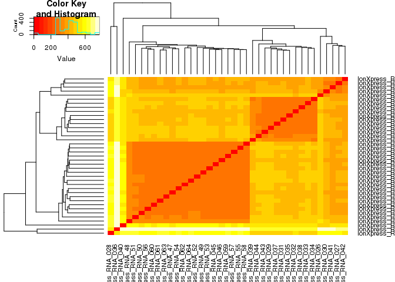

Similarity Matrix for All Samples

# Adipose Tissue

The adipose tissue samples are all eWAT samples

## Adipose Overall Model

This model used only the adipose tissue data, and tested for changes for the interaction between feeding state and diet, then for the main effects of each.

Using the combined model, we identified 2675 transcripts with a significant interaction between feeding and diet in WAT. After removing those genes with an interaction, 204 genes had a main effect with respect to Diet and 215 transcripts had a main effect with respect to Feeding State.

Top Hits for Effects of Diet

|  | ensembl_transcript_id | baseMean | log2FoldChange | lfcSE | stat | pvalue | padj | log2FoldChange_Diet | lfcSE_Diet | pvalue_Diet | padj_Diet | log2FoldChange_Feeding | lfcSE_Feeding | pvalue_Feeding | padj_Feeding | X | gene_biotype | external_gene_name | ensembl_gene_id |
| --- | --- | --- | --- | --- | --- | --- | --- | --- | --- | --- | --- | --- | --- | --- | --- | --- | --- | --- | --- |
| 4584 | ENSMUST00000028114 | 225.8 | 27.6 | 3.56 | 7.74 | 0 | 0 | -24.8 | 2.79 | 0 | 0 | -3.740 | 2.03 | 0.065 | 0.428 | 36045 | protein_coding | Pfkfb3 | ENSMUSG00000026773 |
| 42408 | ENSMUST00000162825 | 162.2 | -23.6 | 3.40 | -6.95 | 0 | 0 | 23.3 | 2.62 | 0 | 0 | 23.898 | 2.71 | 0.000 | 0.000 | 17132 | protein_coding | Fndc3a | ENSMUSG00000033487 |
| 39181 | ENSMUST00000152377 | 72.3 | -27.2 | 3.63 | -7.49 | 0 | 0 | 23.4 | 2.75 | 0 | 0 | 21.738 | 2.85 | 0.000 | 0.000 | 104817 | protein_coding | Ccdc67 | ENSMUSG00000039977 |
| 51368 | ENSMUST00000187711 | 70.3 | 22.8 | 3.45 | 6.60 | 0 | 0 | -22.7 | 2.73 | 0 | 0 | -0.346 | 1.93 | 0.858 | 0.961 | 16764 | protein_coding | Fam46a | ENSMUSG00000032265 |
| 23898 | ENSMUST00000108415 | 151.4 | -23.7 | 4.04 | -5.85 | 0 | 0 | 24.3 | 2.99 | 0 | 0 | 22.190 | 3.11 | 0.000 | 0.000 | 82376 | protein_coding | Pou2f2 | ENSMUSG00000008496 |

Top Hits for Effects of Feeding

|  | ensembl_transcript_id | baseMean | log2FoldChange | lfcSE | stat | pvalue | padj | log2FoldChange_Diet | lfcSE_Diet | pvalue_Diet | padj_Diet | log2FoldChange_Feeding | lfcSE_Feeding | pvalue_Feeding | padj_Feeding | X | gene_biotype | external_gene_name | ensembl_gene_id |
| --- | --- | --- | --- | --- | --- | --- | --- | --- | --- | --- | --- | --- | --- | --- | --- | --- | --- | --- | --- |
| 42408 | ENSMUST00000162825 | 162.2 | -23.6 | 3.40 | -6.95 | 0 | 0 | 23.3 | 2.62 | 0 | 0 | 23.9 | 2.71 | 0 | 0 | 17132 | protein_coding | Fndc3a | ENSMUSG00000033487 |
| 28523 | ENSMUST00000116388 | 58.2 | -21.7 | 3.70 | -5.86 | 0 | 0 | 21.1 | 2.79 | 0 | 0 | 22.9 | 2.90 | 0 | 0 | 30384 | protein_coding | Rcor1 | ENSMUSG00000037896 |
| 27723 | ENSMUST00000114680 | 72.4 | -24.1 | 3.86 | -6.24 | 0 | 0 | 22.7 | 2.88 | 0 | 0 | 22.8 | 2.99 | 0 | 0 | 23837 | protein_coding | Mllt10 | ENSMUSG00000026743 |
| 39181 | ENSMUST00000152377 | 72.3 | -27.2 | 3.63 | -7.49 | 0 | 0 | 23.4 | 2.75 | 0 | 0 | 21.7 | 2.85 | 0 | 0 | 104817 | protein_coding | Ccdc67 | ENSMUSG00000039977 |
| 26087 | ENSMUST00000112098 | 16.2 | -19.2 | 3.53 | -5.43 | 0 | 0 | 18.9 | 2.70 | 0 | 0 | 21.1 | 2.79 | 0 | 0 | 107439 | protein_coding | Pbrm1 | ENSMUSG00000042323 |

Top Hits for Interaction between Diet and Feeding

|  | ensembl_transcript_id | baseMean | log2FoldChange | lfcSE | stat | pvalue | padj | log2FoldChange_Diet | lfcSE_Diet | pvalue_Diet | padj_Diet | log2FoldChange_Feeding | lfcSE_Feeding | pvalue_Feeding | padj_Feeding | X | gene_biotype | external_gene_name | ensembl_gene_id |
| --- | --- | --- | --- | --- | --- | --- | --- | --- | --- | --- | --- | --- | --- | --- | --- | --- | --- | --- | --- |
| 3766 | ENSMUST00000025705 | 268.5 | -24.5 | 3.02 | -8.12 | 0 | 0 | 0.616 | 1.29 | 0.633 | 0.91 | -1.19 | 1.38 | 0.388 | 0.782 | 35050 | protein_coding | Jak2 | ENSMUSG00000024789 |
| 4584 | ENSMUST00000028114 | 225.8 | 27.6 | 3.56 | 7.74 | 0 | 0 | -24.787 | 2.79 | 0.000 | 0.00 | -3.74 | 2.03 | 0.065 | 0.428 | 36045 | protein_coding | Pfkfb3 | ENSMUSG00000026773 |
| 39181 | ENSMUST00000152377 | 72.3 | -27.2 | 3.63 | -7.49 | 0 | 0 | 23.448 | 2.75 | 0.000 | 0.00 | 21.74 | 2.85 | 0.000 | 0.000 | 104817 | protein_coding | Ccdc67 | ENSMUSG00000039977 |
| 45840 | ENSMUST00000171091 | 23.8 | -28.6 | 3.89 | -7.35 | 0 | 0 | 21.849 | 2.74 | 0.000 | 0.00 | 20.40 | 2.84 | 0.000 | 0.000 | 47405 | protein_coding | Iqcf6 | ENSMUSG00000091129 |
| 42408 | ENSMUST00000162825 | 162.2 | -23.6 | 3.40 | -6.95 | 0 | 0 | 23.293 | 2.62 | 0.000 | 0.00 | 23.90 | 2.71 | 0.000 | 0.000 | 17132 | protein_coding | Fndc3a | ENSMUSG00000033487 |

## Effects of Feeding State

This model used only the adipose tissue data, and tested for changes related to the feeding state.

Top Hits for Effects of Feeding

|  | ensembl_transcript_id | baseMean | log2FoldChange | lfcSE | stat | pvalue | padj | X | gene_biotype | external_gene_name | ensembl_gene_id |
| --- | --- | --- | --- | --- | --- | --- | --- | --- | --- | --- | --- |
| 2503 | ENSMUST00000021653 | 23.4 | -23.3 | 2.66 | -8.75 | 0 | 0 | 736 | protein_coding | Acot3 | ENSMUSG00000021228 |
| 43366 | ENSMUST00000165113 | 81.7 | -25.0 | 3.08 | -8.13 | 0 | 0 | 52340 | protein_coding | Tardbp | ENSMUSG00000041459 |
| 6456 | ENSMUST00000033437 | 28.0 | -23.5 | 2.93 | -8.03 | 0 | 0 | 51099 | protein_coding | Enox2 | ENSMUSG00000031109 |
| 8212 | ENSMUST00000040222 | 49.2 | -24.2 | 3.05 | -7.95 | 0 | 0 | 58647 | protein_coding | Crocc | ENSMUSG00000040860 |
| 46808 | ENSMUST00000173372 | 20.5 | -23.1 | 2.91 | -7.93 | 0 | 0 | 90960 | protein_coding | Myo1f | ENSMUSG00000024300 |

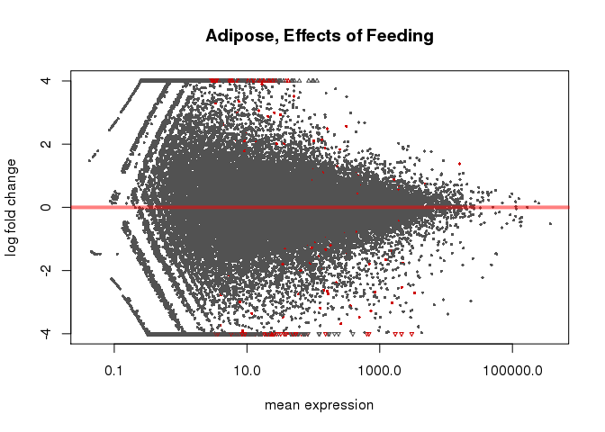

MA Plot for Effects of Feeding Status on Adipose Tissue

We identified 158 differentially expressed transcripts in adipose tissue, out of a total of 55241 transcripts tested. Of these significantly differentially expressed transcripts, 71 were upregulated and 87 were downregulated.

## Effects of Diet Overall

Top Hits for Effects of Diet, Ignoring Feeding

|  | ensembl_transcript_id | baseMean | log2FoldChange | lfcSE | stat | pvalue | padj | X | gene_biotype | external_gene_name | ensembl_gene_id |
| --- | --- | --- | --- | --- | --- | --- | --- | --- | --- | --- | --- |
| 29414 | ENSMUST00000119685 | 28.24 | 10.771 | 1.780 | 37.1 | 0 | 0.000 | 103448 | protein_coding | Uspl1 | ENSMUSG00000041264 |
| 13711 | ENSMUST00000067664 | 4900.36 | 0.241 | 0.045 | 28.5 | 0 | 0.002 | 4107 | protein_coding | Ywhae | ENSMUSG00000020849 |
| 43506 | ENSMUST00000165456 | 6.92 | -8.338 | 1.920 | 18.5 | 0 | 0.241 | 34124 | protein_coding | Slc6a12 | ENSMUSG00000030109 |
| 14928 | ENSMUST00000073833 | 2.18 | -6.641 | 1.782 | 16.6 | 0 | 0.452 | 43154 | protein_coding | Zfp111 | ENSMUSG00000087598 |
| 38664 | ENSMUST00000150685 | 1.95 | -6.433 | 1.759 | 16.4 | 0 | 0.452 | 107855 | protein_coding | Appl2 | ENSMUSG00000020263 |
| 18307 | ENSMUST00000092802 | 56.15 | 11.738 | 2.374 | 15.4 | 0 | 0.540 | 82209 | protein_coding | Mtmr4 | ENSMUSG00000018401 |
| 41890 | ENSMUST00000161738 | 1.14 | -5.735 | 1.685 | 15.3 | 0 | 0.540 | 25820 | protein_coding | Igf2r | ENSMUSG00000023830 |
| 53035 | ENSMUST00000194663 | 13.81 | 9.776 | 2.193 | 15.2 | 0 | 0.540 | 8359 | protein_coding | Ptch1 | ENSMUSG00000021466 |
| 13840 | ENSMUST00000068333 | 569.51 | 0.514 | 0.137 | 14.0 | 0 | 0.569 | 47026 | protein_coding | Farsb | ENSMUSG00000026245 |
| 19386 | ENSMUST00000097921 | 438.07 | 2.395 | 0.616 | 14.0 | 0 | 0.569 | 33569 | protein_coding | Cdkn2c | ENSMUSG00000028551 |

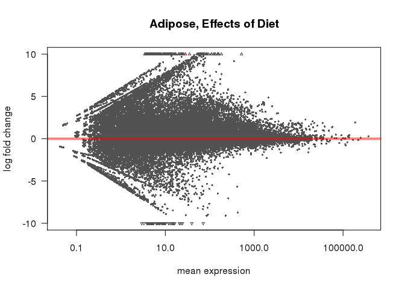

MA Plot for Main Effects of Diet Status on Adipose Tissue

We identified 2 differentially expressed transcripts, out of a total of 55241 transcripts tested.

## Effects of Diet with an Interaction

Top Hits for Effects of Diet

|  | ensembl_transcript_id | baseMean | log2FoldChange | lfcSE | stat | pvalue | padj | log2FC_HFDvsControl | lfcSE_HFDvsControl | X | gene_biotype | external_gene_name | ensembl_gene_id |
| --- | --- | --- | --- | --- | --- | --- | --- | --- | --- | --- | --- | --- | --- |
| 29414 | ENSMUST00000119685 | 28.2 | -1.040 | 3.646 | 36.1 | 0 | 0.001 | 11.192 | 2.329 | 103448 | protein_coding | Uspl1 | ENSMUSG00000041264 |
| 20497 | ENSMUST00000100832 | 16.1 | -9.218 | 2.334 | 34.2 | 0 | 0.001 | 9.649 | 2.073 | 104597 | protein_coding | Recql | ENSMUSG00000030243 |
| 1070 | ENSMUST00000009102 | 787.2 | -0.422 | 0.112 | 32.9 | 0 | 0.001 | 0.418 | 0.073 | 80648 | protein_coding | Vps72 | ENSMUSG00000008958 |
| 15682 | ENSMUST00000077472 | 64.0 | 13.401 | 2.688 | 31.1 | 0 | 0.002 | -11.730 | 2.333 | 108372 | protein_coding | Chst15 | ENSMUSG00000030930 |
| 11110 | ENSMUST00000054083 | 425.2 | 18.461 | 3.105 | 27.7 | 0 | 0.006 | -13.448 | 2.545 | 65681 | protein_coding | Ermp1 | ENSMUSG00000046324 |
| 13711 | ENSMUST00000067664 | 4900.4 | -0.039 | 0.094 | 26.9 | 0 | 0.006 | 0.257 | 0.061 | 4107 | protein_coding | Ywhae | ENSMUSG00000020849 |
| 17131 | ENSMUST00000086112 | 1197.9 | -0.771 | 0.279 | 26.9 | 0 | 0.006 | 0.931 | 0.182 | 50609 | protein_coding | Ap2s1 | ENSMUSG00000008036 |
| 24650 | ENSMUST00000109646 | 22.1 | -8.793 | 1.602 | 27.6 | 0 | 0.006 | 4.643 | 1.018 | 61660 | protein_coding | Fam227a | ENSMUSG00000042564 |
| 26203 | ENSMUST00000112266 | 144.0 | -13.996 | 2.878 | 27.3 | 0 | 0.006 | 1.535 | 1.142 | 103482 | protein_coding | Phospho2 | ENSMUSG00000027088 |
| 58 | ENSMUST00000000342 | 221.9 | 6.484 | 1.168 | 26.6 | 0 | 0.006 | -3.563 | 0.761 | 97241 | protein_coding | Ccl11 | ENSMUSG00000020676 |

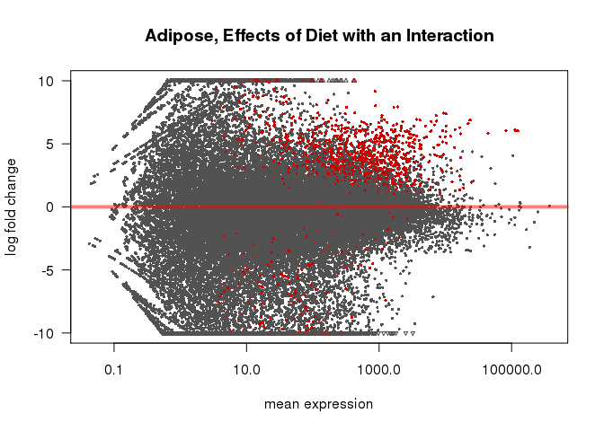

MA Plot for Effects of Diet Status on Adipose Tissue

We identified 914 differentially expressed transcripts, out of a total of 55241 transcripts tested. Of these significantly differentially expressed transcripts, 718 were upregulated and 196 were downregulated.

# Muscle Tissue

The muscle tissue samples are all quadriceps samples

## Muscle Overall Model

This model used only the quadricep tissue data, and tested for changes for the interaction between feeding state and diet, then for the main effects of each.

Using the combined model, we identified 115 transcripts with a significant interaction between feeding and diet in quad. After removing those genes with an interaction, 63 genes had a main effect with respect to Diet and 3632 transcripts had a main effect with respect to Feeding State.

Top Hits for Effects of Diet

|  | ensembl_transcript_id | baseMean | log2FoldChange | lfcSE | stat | pvalue | padj | log2FoldChange_Diet | lfcSE_Diet | pvalue_Diet | padj_Diet | log2FoldChange_Feeding | lfcSE_Feeding | pvalue_Feeding | padj_Feeding | X | gene_biotype | external_gene_name | ensembl_gene_id |
| --- | --- | --- | --- | --- | --- | --- | --- | --- | --- | --- | --- | --- | --- | --- | --- | --- | --- | --- | --- |
| 46123 | ENSMUST00000171751 | 38.5 | 21.94 | 3.11 | 7.057 | 0.000 | 0 | -21.9 | 2.44 | 0 | 0 | 0.695 | 1.76 | 0.693 | 0.915 | 29498 | protein_coding | Rbfox2 | ENSMUSG00000033565 |
| 43952 | ENSMUST00000166592 | 51.2 | 20.08 | 3.44 | 5.838 | 0.000 | 0 | -22.9 | 2.61 | 0 | 0 | 0.636 | 2.04 | 0.755 | 0.938 | 27498 | protein_coding | Tnpo2 | ENSMUSG00000031691 |
| 46214 | ENSMUST00000171999 | 12.2 | 20.51 | 3.69 | 5.559 | 0.000 | 0 | -20.6 | 2.74 | 0 | 0 | 0.404 | 2.25 | 0.858 | 0.966 | 21759 | protein_coding | Gcat | ENSMUSG00000006378 |
| 43 | ENSMUST00000000284 | 14.9 | -4.31 | 4.98 | -0.865 | 0.387 | 1 | -22.6 | 3.15 | 0 | 0 | -0.514 | 2.84 | 0.856 | 0.966 | 103841 | protein_coding | Trim25 | ENSMUSG00000000275 |
| 41174 | ENSMUST00000160132 | 13.7 | -21.76 | 3.64 | -5.980 | 0.000 | 0 | 19.0 | 2.71 | 0 | 0 | 21.270 | 2.88 | 0.000 | 0.000 | 63327 | protein_coding | Eif4g2 | ENSMUSG00000005610 |

Top Hits for Effects of Feeding

|  | ensembl_transcript_id | baseMean | log2FoldChange | lfcSE | stat | pvalue | padj | log2FoldChange_Diet | lfcSE_Diet | pvalue_Diet | padj_Diet | log2FoldChange_Feeding | lfcSE_Feeding | pvalue_Feeding | padj_Feeding | X | gene_biotype | external_gene_name | ensembl_gene_id |
| --- | --- | --- | --- | --- | --- | --- | --- | --- | --- | --- | --- | --- | --- | --- | --- | --- | --- | --- | --- |
| 13650 | ENSMUST00000067354 | 2846 | 0.553 | 0.425 | 1.299 | 0.194 | 1 | 0.156 | 0.251 | 0.535 | 1.00 | -6.99 | 0.306 | 0 | 0 | 142 | protein_coding | 8430408G22Rik | ENSMUSG00000048489 |
| 3616 | ENSMUST00000025279 | 3766 | -0.213 | 0.131 | -1.625 | 0.104 | 1 | 0.181 | 0.081 | 0.026 | 0.72 | -1.87 | 0.093 | 0 | 0 | 68773 | protein_coding | Npc1 | ENSMUSG00000024413 |
| 22257 | ENSMUST00000105875 | 27633 | -0.043 | 0.251 | -0.171 | 0.864 | 1 | -0.004 | 0.159 | 0.981 | 1.00 | -3.51 | 0.178 | 0 | 0 | 81577 | protein_coding | Trim63 | ENSMUSG00000028834 |
| 29184 | ENSMUST00000118936 | 2787 | -0.106 | 0.149 | -0.710 | 0.477 | 1 | 0.013 | 0.093 | 0.891 | 1.00 | -1.79 | 0.105 | 0 | 0 | 107766 | protein_coding | Gucd1 | ENSMUSG00000033416 |
| 20988 | ENSMUST00000102745 | 931 | -0.192 | 0.269 | -0.715 | 0.474 | 1 | 0.204 | 0.174 | 0.239 | 1.00 | 2.96 | 0.190 | 0 | 0 | 49555 | protein_coding | Tnfaip2 | ENSMUSG00000021281 |

Top Hits for Interaction between Diet and Feeding

|  | ensembl_transcript_id | baseMean | log2FoldChange | lfcSE | stat | pvalue | padj | log2FoldChange_Diet | lfcSE_Diet | pvalue_Diet | padj_Diet | log2FoldChange_Feeding | lfcSE_Feeding | pvalue_Feeding | padj_Feeding | X | gene_biotype | external_gene_name | ensembl_gene_id |
| --- | --- | --- | --- | --- | --- | --- | --- | --- | --- | --- | --- | --- | --- | --- | --- | --- | --- | --- | --- |
| 24491 | ENSMUST00000109394 | 98.45 | -23.6 | 3.30 | -7.15 | 0 | 0 | -0.807 | 1.51 | 0.593 | 1.000 | 0.487 | 1.69 | 0.773 | 0.944 | 77362 | protein_coding | Cbfb | ENSMUSG00000031885 |
| 46123 | ENSMUST00000171751 | 38.46 | 21.9 | 3.11 | 7.06 | 0 | 0 | -21.907 | 2.44 | 0.000 | 0.000 | 0.695 | 1.76 | 0.693 | 0.915 | 29498 | protein_coding | Rbfox2 | ENSMUSG00000033565 |
| 53016 | ENSMUST00000194592 | 2.95 | -30.0 | 4.27 | -7.02 | 0 | 0 | 14.058 | 2.71 | 0.000 | 0.000 | 16.365 | 2.86 | 0.000 | 0.000 | 57770 | protein_coding | Serpinc1 | ENSMUSG00000026715 |
| 42991 | ENSMUST00000164235 | 58.90 | -24.5 | 3.60 | -6.80 | 0 | 0 | 1.346 | 1.76 | 0.445 | 1.000 | 0.919 | 1.97 | 0.641 | 0.894 | 60867 | protein_coding | Mapk1ip1l | ENSMUSG00000021840 |
| 23732 | ENSMUST00000108183 | 15.07 | -30.0 | 4.72 | -6.35 | 0 | 0 | 14.336 | 2.99 | 0.000 | 0.001 | 16.187 | 3.21 | 0.000 | 0.000 | 34407 | protein_coding | Map3k7 | ENSMUSG00000028284 |

## Effects of Feeding State

This model used only the quadriceps tissue data, and tested for changes related to the feeding state.

Top Hits for Effects of Feeding

|  | ensembl_transcript_id | baseMean | log2FoldChange | lfcSE | stat | pvalue | padj | X | gene_biotype | external_gene_name | ensembl_gene_id |
| --- | --- | --- | --- | --- | --- | --- | --- | --- | --- | --- | --- |
| 13650 | ENSMUST00000067354 | 2846 | -6.67 | 0.223 | -29.9 | 0 | 0 | 142 | protein_coding | 8430408G22Rik | ENSMUSG00000048489 |
| 22257 | ENSMUST00000105875 | 27633 | -3.54 | 0.119 | -29.6 | 0 | 0 | 81577 | protein_coding | Trim63 | ENSMUSG00000028834 |
| 3616 | ENSMUST00000025279 | 3766 | -1.98 | 0.071 | -27.9 | 0 | 0 | 68773 | protein_coding | Npc1 | ENSMUSG00000024413 |
| 29184 | ENSMUST00000118936 | 2787 | -1.84 | 0.072 | -25.7 | 0 | 0 | 107766 | protein_coding | Gucd1 | ENSMUSG00000033416 |
| 2984 | ENSMUST00000022986 | 31906 | -3.19 | 0.138 | -23.2 | 0 | 0 | 4159 | protein_coding | Fbxo32 | ENSMUSG00000022358 |

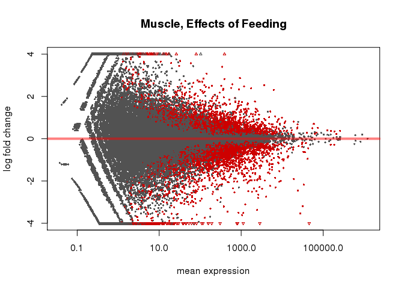

MA Plot for Effects of Feeding Status on Muscle Tissue

We identified 5681 differentially expressed transcripts in muscle tissue, out of a total of 55241 transcripts tested. Of these significantly differentially expressed transcripts, 2620 were upregulated and 3061 were downregulated.

## Effects of Diet

Top Hits for Effects of Diet

|  | ensembl_transcript_id | baseMean | log2FoldChange | lfcSE | stat | pvalue | padj | log2FC_HFDvsControl | lfcSE_HFDvsControl | X | gene_biotype | external_gene_name | ensembl_gene_id |
| --- | --- | --- | --- | --- | --- | --- | --- | --- | --- | --- | --- | --- | --- |
| 28428 | ENSMUST00000115785 | 96.68 | -11.779 | 2.417 | 68.1 | 0 | 0.000 | 0.738 | 0.507 | 83449 | protein_coding | Synj2 | ENSMUSG00000023805 |
| 44074 | ENSMUST00000166930 | 46.20 | -6.297 | 1.308 | 55.3 | 0 | 0.000 | -0.857 | 0.521 | 64038 | protein_coding | Morf4l2 | ENSMUSG00000031422 |
| 23731 | ENSMUST00000108182 | 28.15 | -10.229 | 2.547 | 37.3 | 0 | 0.000 | -0.373 | 0.725 | 8103 | protein_coding | Dcun1d1 | ENSMUSG00000027708 |
| 52528 | ENSMUST00000192305 | 56.91 | -0.672 | 0.904 | 32.3 | 0 | 0.001 | -2.318 | 0.548 | 82362 | protein_coding | Uqcrc1 | ENSMUSG00000025651 |
| 44421 | ENSMUST00000167764 | 495.77 | -0.563 | 0.209 | 28.3 | 0 | 0.005 | -0.254 | 0.130 | 86186 | protein_coding | Fgfr1 | ENSMUSG00000031565 |
| 14366 | ENSMUST00000071152 | 35.43 | 11.503 | 2.693 | 25.8 | 0 | 0.011 | -1.569 | 0.909 | 102808 | protein_coding | Rffl | ENSMUSG00000020696 |
| 19831 | ENSMUST00000099131 | 801.93 | -0.009 | 0.106 | 26.1 | 0 | 0.011 | 0.266 | 0.066 | 33088 | protein_coding | Smarcc2 | ENSMUSG00000025369 |
| 29868 | ENSMUST00000121114 | 529.68 | 0.036 | 0.163 | 25.8 | 0 | 0.011 | -0.411 | 0.099 | 92692 | protein_coding | Slc43a1 | ENSMUSG00000027075 |
| 5468 | ENSMUST00000030508 | 53.77 | -0.627 | 0.286 | 25.0 | 0 | 0.011 | 0.890 | 0.184 | 54259 | protein_coding | Pax7 | ENSMUSG00000028736 |
| 33009 | ENSMUST00000131679 | 1.68 | 0.480 | 3.227 | 25.3 | 0 | 0.011 | -6.738 | 2.036 | 43499 | protein_coding | Tchp | ENSMUSG00000002486 |

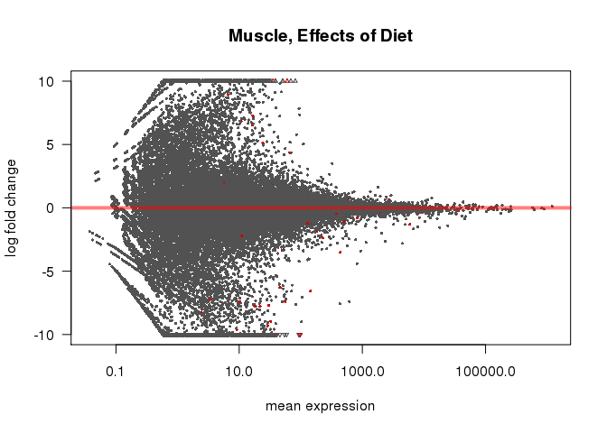

We identified 45 differentially expressed transcripts in quadriceps, out of a total of 55241 transcripts tested. Of these significantly differentially expressed transcripts, 16 were upregulated and 29 were downregulated.

## Effects of Diet with an Interaction

Top Hits for Effects of Diet with An Interaction

|  | ensembl_transcript_id | baseMean | log2FoldChange | lfcSE | stat | pvalue | padj | log2FC_HFDvsControl | lfcSE_HFDvsControl | X | gene_biotype | external_gene_name | ensembl_gene_id |
| --- | --- | --- | --- | --- | --- | --- | --- | --- | --- | --- | --- | --- | --- |
| 28428 | ENSMUST00000115785 | 96.68 | -11.779 | 2.417 | 68.1 | 0 | 0.000 | 0.738 | 0.507 | 83449 | protein_coding | Synj2 | ENSMUSG00000023805 |
| 44074 | ENSMUST00000166930 | 46.20 | -6.297 | 1.308 | 55.3 | 0 | 0.000 | -0.857 | 0.521 | 64038 | protein_coding | Morf4l2 | ENSMUSG00000031422 |
| 23731 | ENSMUST00000108182 | 28.15 | -10.229 | 2.547 | 37.3 | 0 | 0.000 | -0.373 | 0.725 | 8103 | protein_coding | Dcun1d1 | ENSMUSG00000027708 |
| 52528 | ENSMUST00000192305 | 56.91 | -0.672 | 0.904 | 32.3 | 0 | 0.001 | -2.318 | 0.548 | 82362 | protein_coding | Uqcrc1 | ENSMUSG00000025651 |
| 44421 | ENSMUST00000167764 | 495.77 | -0.563 | 0.209 | 28.3 | 0 | 0.005 | -0.254 | 0.130 | 86186 | protein_coding | Fgfr1 | ENSMUSG00000031565 |
| 14366 | ENSMUST00000071152 | 35.43 | 11.503 | 2.693 | 25.8 | 0 | 0.011 | -1.569 | 0.909 | 102808 | protein_coding | Rffl | ENSMUSG00000020696 |
| 19831 | ENSMUST00000099131 | 801.93 | -0.009 | 0.106 | 26.1 | 0 | 0.011 | 0.266 | 0.066 | 33088 | protein_coding | Smarcc2 | ENSMUSG00000025369 |
| 29868 | ENSMUST00000121114 | 529.68 | 0.036 | 0.163 | 25.8 | 0 | 0.011 | -0.411 | 0.099 | 92692 | protein_coding | Slc43a1 | ENSMUSG00000027075 |
| 5468 | ENSMUST00000030508 | 53.77 | -0.627 | 0.286 | 25.0 | 0 | 0.011 | 0.890 | 0.184 | 54259 | protein_coding | Pax7 | ENSMUSG00000028736 |
| 33009 | ENSMUST00000131679 | 1.68 | 0.480 | 3.227 | 25.3 | 0 | 0.011 | -6.738 | 2.036 | 43499 | protein_coding | Tchp | ENSMUSG00000002486 |

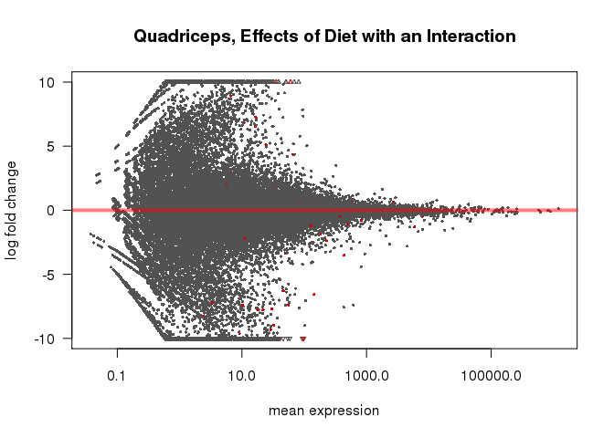

MA Plot for Effects of Diet Status on Quadriceps Tissue

We identified 45 differentially expressed transcripts, out of a total of 55241 transcripts tested. Of these significantly differentially expressed transcripts, 16 were upregulated and 29 were downregulated.